# WMAN 633 Homework 7

Joe Kingsbury

## **Question 1**

Load data and place into an unmarkedFrameOccu object

```r
#Set working directory
#setwd(choose.dir())
bobcat <- read.csv("Bobcat.csv") # detection/non-detection data
p_covs <- read.csv("p covariates.csv") #Detection covarites
psi_covs <- read.csv("psi covariates.csv") #Site level covairates

bobcat_mat <- as.matrix(bobcat)

det_covs <- list(
  People = data.frame(p_covs[,c(1:71)]))
head(det_covs$People)
```

|  | People1 | People2 | People3 | People4 | People5 | People6 | People7 | People8 | People9 | People10 | People11 | People12 | People13 | People14 | People15 | People16 | People17 | People18 | People19 | People20 | People21 | People22 | People23 | People24 | People25 | People26 | People27 | People28 | People29 | … |
| --- | --- | --- | --- | --- | --- | --- | --- | --- | --- | --- | --- | --- | --- | --- | --- | --- | --- | --- | --- | --- | --- | --- | --- | --- | --- | --- | --- | --- | --- | --- |
| 1 | 0.82 | 0.25 | 0.15 | 0.09 | 0.07 | 0.28 | 1.39 | 1.14 | 0.13 | 0.43 | 0.44 | 0.63 | 0.26 | 1.15 | 0.43 | 0.00 | 0.00 | 0.00 | 0.00 | 0.00 | 0.0 | 0.91 | NA | NA | NA | NA | NA | NA | NA | … |
| 2 | 0.00 | 0.00 | 0.00 | 0.00 | 0.00 | 0.00 | 0.00 | 0.00 | 0.00 | 0.00 | 0.00 | 0.00 | 0.00 | 0.00 | 0.00 | 0.00 | 0.00 | 0.00 | 0.00 | 0.00 | NA | NA | NA | NA | NA | NA | NA | NA | NA | … |
| 3 | 0.74 | 0.12 | 0.18 | 0.59 | 0.53 | 0.41 | 1.03 | 0.53 | 0.15 | 0.32 | 0.34 | 0.19 | 0.20 | 0.96 | NA | NA | NA | NA | NA | NA | NA | NA | NA | NA | NA | NA | NA | NA | NA | … |
| 4 | 0.00 | 0.00 | 0.00 | 0.00 | 0.00 | 0.00 | 0.00 | 0.00 | 0.00 | 0.00 | 0.00 | 0.00 | 0.00 | 0.01 | 0.01 | 0.00 | 0.00 | 0.00 | NA | NA | NA | NA | NA | NA | NA | NA | NA | NA | NA | … |
| 5 | 0.00 | 0.00 | 0.00 | 0.00 | 0.00 | 0.00 | 0.00 | 0.00 | 0.00 | 0.00 | 0.00 | 0.00 | 0.00 | 0.02 | 0.00 | 0.00 | 0.00 | 0.00 | 0.00 | 0.00 | 0.0 | NA | NA | NA | NA | NA | NA | NA | NA | … |
| 6 | 0.37 | 0.24 | 0.06 | 0.14 | 0.10 | 0.22 | 0.53 | 0.32 | 0.06 | 0.02 | 0.01 | 0.06 | 0.09 | 0.37 | 0.55 | 0.05 | 0.04 | 0.06 | 0.19 | 0.19 | 0.2 | NA | NA | NA | NA | NA | NA | NA | NA | … |

```r
library(unmarked)

occu_data <- unmarkedFrameOccu(y = bobcat_mat, siteCovs = psi_covs, obsCovs = det_covs)
head(occu_data)
```

```
Data frame representation of unmarkedFrame object.
```

|  | y.1 | y.2 | y.3 | y.4 | y.5 | y.6 | y.7 | y.8 | y.9 | y.10 | y.11 | y.12 | y.13 | y.14 | y.15 | y.16 | y.17 | y.18 | y.19 | y.20 | y.21 | y.22 | y.23 | y.24 | y.25 | y.26 | y.27 | y.28 | y.29 | … |
| --- | --- | --- | --- | --- | --- | --- | --- | --- | --- | --- | --- | --- | --- | --- | --- | --- | --- | --- | --- | --- | --- | --- | --- | --- | --- | --- | --- | --- | --- | --- |
| 1 | 0 | 0 | 0 | 0 | 0 | 0 | 0 | 0 | 0 | 0 | 0 | 0 | 0 | 0 | 0 | 0 | 0 | 0 | 0 | 0 | 0 | 0 | NA | NA | NA | NA | NA | NA | NA | … |
| 2 | 0 | 0 | 0 | 0 | 0 | 0 | 0 | 0 | 0 | 0 | 0 | 0 | 0 | 0 | 0 | 0 | 0 | 0 | 0 | 0 | NA | NA | NA | NA | NA | NA | NA | NA | NA | … |
| 3 | 0 | 0 | 0 | 0 | 0 | 0 | 0 | 0 | 0 | 0 | 0 | 0 | 0 | 0 | NA | NA | NA | NA | NA | NA | NA | NA | NA | NA | NA | NA | NA | NA | NA | … |
| 4 | 0 | 0 | 0 | 0 | 0 | 0 | 0 | 0 | 0 | 0 | 0 | 0 | 0 | 0 | 0 | 0 | 0 | 0 | NA | NA | NA | NA | NA | NA | NA | NA | NA | NA | NA | … |
| 5 | 0 | 0 | 0 | 0 | 0 | 0 | 0 | 0 | 0 | 0 | 0 | 0 | 0 | 0 | 0 | 0 | 0 | 0 | 0 | 0 | 0 | NA | NA | NA | NA | NA | NA | NA | NA | … |
| 6 | 0 | 0 | 0 | 0 | 0 | 0 | 0 | 0 | 0 | 0 | 0 | 0 | 0 | 0 | 0 | 0 | 0 | 0 | 0 | 0 | 0 | NA | NA | NA | NA | NA | NA | NA | NA | … |
| 7 | 0 | 0 | 0 | 0 | 0 | 0 | 0 | 0 | 0 | 0 | 0 | 0 | 0 | 0 | 0 | 0 | 0 | 0 | 0 | 0 | 0 | NA | NA | NA | NA | NA | NA | NA | NA | … |
| 8 | 0 | 0 | 0 | 0 | 0 | 0 | 0 | 0 | 0 | 0 | 0 | 0 | 0 | 0 | 0 | 0 | 0 | 0 | 0 | 0 | 0 | NA | NA | NA | NA | NA | NA | NA | NA | … |
| 9 | 0 | 0 | 0 | 0 | 0 | 0 | 0 | 0 | 0 | 0 | 0 | 0 | 0 | 0 | 0 | 0 | 0 | 0 | 0 | 0 | 0 | 0 | 0 | 0 | 0 | 0 | 0 | 0 | 0 | … |
| 10 | 0 | 0 | 0 | 0 | 0 | 0 | 0 | 0 | 0 | 0 | 0 | 0 | 0 | 0 | 0 | 0 | 0 | 0 | 0 | 0 | 0 | 0 | 0 | 0 | 0 | 0 | 0 | 0 | 0 | … |

## **Question 2**

Fit the following candidate set of models:

| Detection model | Occupancy model |
| --- | --- |
| intercept-only | intercept-only |
| people | intercept-only |
| intercept-only | disturbance |
| people | disturbance |

```r
fit1 <- occu(~ 1 ~ 1, data = occu_data)
fit2 <- occu(~ People ~ 1, data = occu_data)
fit3 <- occu(~ 1 ~ Dist_5km, data = occu_data)
fit4 <- occu(~ People ~ Dist_5km, data = occu_data)
summary(fit1)
```

```
Call:
occu(formula = ~1 ~ 1, data = occu_data)

Occupancy (logit-scale):
```

|  | Estimate | SE | z | P(>\|z\|) |
| --- | --- | --- | --- | --- |
| (Intercept) | -1.318221 | 0.08789472 | -14.99772 | 7.598086e-51 |

```
Detection (logit-scale):
```

|  | Estimate | SE | z | P(>\|z\|) |
| --- | --- | --- | --- | --- |
| (Intercept) | -3.016469 | 0.07344396 | -41.07171 | 0 |

```
AIC: 4490.771
Number of sites: 1951
optim convergence code: 0
optim iterations: 29
Bootstrap iterations: 0
```

```r
summary(fit2)
```

```
Call:
occu(formula = ~People ~ 1, data = occu_data)

Occupancy (logit-scale):
```

|  | Estimate | SE | z | P(>\|z\|) |
| --- | --- | --- | --- | --- |
| (Intercept) | -1.317658 | 0.08793198 | -14.98497 | 9.206538e-51 |

```
Detection (logit-scale):
```

|  | Estimate | SE | z | P(>\|z\|) |
| --- | --- | --- | --- | --- |
| (Intercept) | -3.01412366 | 0.07433097 | -40.5500393 | 0.0000000 |
| People | -0.07649068 | 0.37591564 | -0.2034783 | 0.8387612 |

```
AIC: 4492.729
Number of sites: 1951
optim convergence code: 0
optim iterations: 35
Bootstrap iterations: 0
```

```r
summary(fit3)
```

```
Call:
occu(formula = ~1 ~ Dist_5km, data = occu_data)

Occupancy (logit-scale):
```

|  | Estimate | SE | z | P(>\|z\|) |
| --- | --- | --- | --- | --- |
| (Intercept) | -1.04647 | 0.1006016 | -10.402116 | 2.424873e-25 |
| Dist_5km | -23.65295 | 4.7734519 | -4.955104 | 7.229177e-07 |

```
Detection (logit-scale):
```

|  | Estimate | SE | z | P(>\|z\|) |
| --- | --- | --- | --- | --- |
| (Intercept) | -3.015056 | 0.07319379 | -41.19279 | 0 |

```
AIC: 4461.006
Number of sites: 1951
optim convergence code: 0
optim iterations: 52
Bootstrap iterations: 0
```

```r
summary(fit4)
```

```
Call:
occu(formula = ~People ~ Dist_5km, data = occu_data)

Occupancy (logit-scale):
```

|  | Estimate | SE | z | P(>\|z\|) |
| --- | --- | --- | --- | --- |
| (Intercept) | -1.045846 | 0.1006168 | -10.394342 | 2.630969e-25 |
| Dist_5km | -23.643839 | 4.7728768 | -4.953792 | 7.278098e-07 |

```
Detection (logit-scale):
```

|  | Estimate | SE | z | P(>\|z\|) |
| --- | --- | --- | --- | --- |
| (Intercept) | -3.01330391 | 0.07413527 | -40.6460250 | 0.0000000 |
| People | -0.06088908 | 0.37794059 | -0.1611075 | 0.8720087 |

```
AIC: 4462.98
Number of sites: 1951
optim convergence code: 0
optim iterations: 39
Bootstrap iterations: 0
```

## **Question 3**

Perform model selection with AIC. What is your top model? How do you know? Is there model selection uncertainty?

```r
library(AICcmodavg)
occu_cand.set <- list(
  F1 = fit1, F2 = fit2, F3 = fit3, F4 = fit4)

occu_mods <- aictab(cand.set = occu_cand.set, second.ord = F)
occu_mods
```

```
Model selection based on AIC:

   K     AIC Delta_AIC AICWt Cum.Wt       LL
F3 3 4461.01      0.00  0.73   0.73 -2227.50
F4 4 4462.98      1.97  0.27   1.00 -2227.49
F1 2 4490.77     29.77  0.00   1.00 -2243.39
F2 3 4492.73     31.72  0.00   1.00 -2243.36
```

My top model is model 3, fit3, which uses the intercept-only for the detection model and the disturbance within 5km for the abundance model. I know this is my top model because the $\Delta$AIC for Model 1 and Model 2 is greater than 2. There is some uncertainty between model 3 and model because the $\Delta$AIC between Model 3 and Model 4 is less than 2.

## **Question 4**

Average both the effect of people on detection, and disturbance on occupancy, over all models. Report model-averaged slope coefficients and 95% confidence intervals.

```r
#People's effect on detection across all models
people_avg <- modavgShrink(cand.set = occu_cand.set, parm = 'People', second.ord = F, parm.type = 'detect')

People_slopecoef <- people_avg$Mod.avg.beta
People_slopecoef
```

```
[1] -0.01653469
```

```r
people_95 <- cbind(people_avg$Lower.CL,people_avg$Upper.CL)
people_95
```

```
           [,1]      [,2]
[1,] -0.4061781 0.3731087
```

```r
#Effect of disturbance on occupancy across all models
dist_avg <- modavgShrink(cand.set = occu_cand.set, parm = 'Dist_5km', second.ord = F, parm.type = 'psi')

Dist_5km_slopecoef <-  dist_avg$Mod.avg.beta
Dist_5km_slopecoef
```

```
[1] -23.65047
```

```r
dist_95 <- cbind(dist_avg$Lower.CL, dist_avg$Upper.CL)
dist_95
```

```
        [,1]      [,2]
[1,] -33.006 -14.29494
```

## **Question 5**

Obtain and plot model-averaged predictions of occupancy probability and detection probability. Average over all models, and make predictions over the observed range of each variable.

```r
#Detection predictions
p_covs[is.na(p_covs)] = 0 #Necessary because you can't generate new data with NAs
new_p <- data.frame(
  People = seq(min(p_covs[1:71]), to = max(p_covs[1:71]), length.out = 100))

avg_prd_det <- modavgPred(cand.set = occu_cand.set, newdata = new_p, second.ord = F, parm.type = 'detect')
avg_prd_det
```

```
Model-averaged predictions on the response scale
based on entire model set and 95% confidence interval:

    mod.avg.pred uncond.se lower.CL upper.CL
1          0.047     0.003    0.041    0.054
2          0.047     0.003    0.041    0.054
3          0.047     0.003    0.041    0.054
4          0.047     0.003    0.040    0.054
5          0.047     0.004    0.040    0.054
6          0.047     0.004    0.039    0.055
7          0.047     0.004    0.039    0.056
8          0.046     0.005    0.038    0.056
9          0.046     0.005    0.038    0.057
10         0.046     0.005    0.037    0.058
11         0.046     0.006    0.036    0.059
```

[output cut: 89 more lines]

```r
plot(x = new_p$People, y = avg_prd_det$mod.avg.pred, type = 'l', ylab = 'Predicted Detection Probability', xlab = 'People', ylim = c(0, max(avg_prd_det$upper.CL)))
lines(x = new_p$People, y = avg_prd_det$upper.CL, lwd = 1, lty = 2)
```

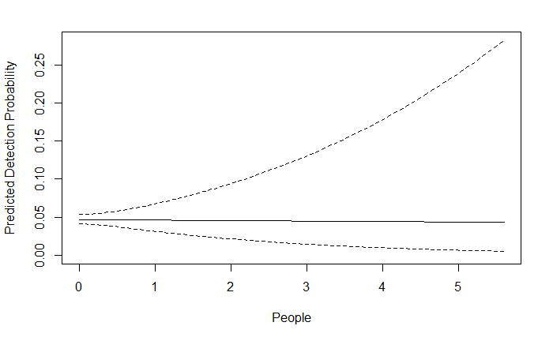

```r
lines(x = new_p$People, y = avg_prd_det$lower.CL , lty = 2)
```

```r
#Occupancy predictions
new_psi <- data.frame(Dist_5km = seq(from = min(psi_covs), to = max(psi_covs), length.out = 100))
new_psi
```

| Dist_5km |
| --- |
| 0.000000000 |
| 0.001313131 |
| 0.002626263 |
| 0.003939394 |
| 0.005252525 |
| 0.006565657 |
| 0.007878788 |
| 0.009191919 |
| 0.010505051 |
| 0.011818182 |

[output cut: 90 more lines]

```r
avg_prd_occupancy <- modavgPred(cand.set = occu_cand.set, newdata = new_psi, second.ord = F, parm.type = 'psi')
avg_prd_occupancy
```

```
Model-averaged predictions on the response scale
based on entire model set and 95% confidence interval:

    mod.avg.pred uncond.se lower.CL upper.CL
1          0.260     0.019    0.224    0.300
2          0.254     0.019    0.219    0.292
3          0.248     0.018    0.215    0.285
4          0.242     0.017    0.210    0.278
5          0.237     0.017    0.206    0.271
6          0.231     0.016    0.201    0.264
7          0.226     0.016    0.196    0.258
8          0.220     0.015    0.192    0.252
9          0.215     0.015    0.187    0.246
10         0.210     0.015    0.182    0.241
11         0.205     0.015    0.177    0.235
```

[output cut: 89 more lines]

```r
plot(x = new_psi$Dist_5km, y = avg_prd_occupancy$mod.avg.pred, type = 'l', ylab = 'Predicted Occupancy Probability', xlab = 'Disturbance within 5km')
lines(x = new_psi$Dist_5km, y = avg_prd_occupancy$upper.CL, lwd = 1, lty = 2)
```

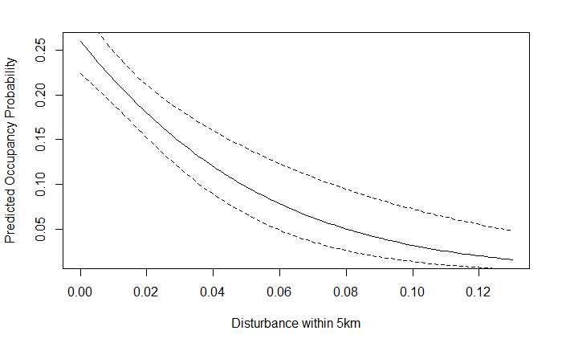

```r
lines(x = new_psi$Dist_5km, y = avg_prd_occupancy$lower.CL , lty = 2)
```